# Introduction to Short-reads Bulk RNA-Seq data analysis

Cancer Genomics & Transcriptomics Course, EMBL-EBI

Alexey Larionov

27 June 2024

# 1. Introduction

Numerous tools and algorithms have been developed for RNA-Seq data. This session aims to provide practical experience with just a few selected tasks and tools, focusing on short-read bulk RNA-seq. This handout shows only the key elements of the code. The full code is provided in the accompanying scripts.

## 1.1 Reproducible research

During the previous days, you already learned how to perform analysis by entering commands in terminal. However, it is not always good for **reproducible research**. To follow **reproducible research** principles, even simple steps of the analysis should be performed using scripts. Moreover, the scripts output should be recorded in logs; ideally, recording even the versions of software and resources.

In this tutorial, all tasks will be performed by Bash or R-markdown scripts. The output of Bash scripts can be captured to log files like this:

```bash
./script.sh &> log.txt
```

Here the **./script.sh** starts the script and **&> log.txt** directs standard output and errors to the log.

If you wish, you may watch the progress of the script while recording the output to a log. For instance, it could be done by using the following commands:

```bash
./script.sh &> log.txt & # Start scripts in background with recording output to the log

tail -f log.txt # Watch the log, following its updates
```

- Note **&** at the end of the first command: it sends the script’s process to background, returning control to the terminal.
- Then note the the **tail** command with **-f** option: it allows to follow the log updates as they happen. Use **ctr-C** keys combination to stop **tail** command when necessary.

For analysis in **R**, **reproducible research** is greatly facilitated by using **R-markdown** (hence: **Rmd** extension). The benefits of **Rmd** scripts are that they allow to record *commands*, their *outputs* and well formatted *comments* into nice-looking **html** or **pdf** reports (by the way, this document was prepared in **R-markdown** too).

In our practical session, most of the software tools’ versions will be explicitly reported by the scripts. The resources’ versions are usually included into the names of the respective files and folders.

## 1.2 Environment

### 1.2.1 VM specifications

Check the number of cores and amount of memory available on your machine (hint: use the provided GUI tool or **htop** command in terminal). Some of the tools allow multi-processing: the number of requested threads should not exceed the number of physically available cores. Some of the tools in this session will request **14 threads** and will need **at least 32GB** of RAM: make sure you have these resources available.

### 1.2.2 Working folder

Explore the **~/bulk-rnaseq/short-reads** folder in your home directory. It should contain sub-folders for **scripts**, **data**, **resources** and **results**. There is no actual results in the folder yet: hopefully, you will make some during this session.

There is a similar folder on **penelopeCloud** drive. It contains copies of the source data, resources, scripts *and expected results*. You may copy files from **penelopeprime** to your home folder, if you need. However, don’t run, remove or modify any files directly on **penelopeCloud**.

### 1.2.3 CTAT resources library

In your **resources** folder you can see **GRCh38_gencode_v37_CTAT_lib_Mar012021** subfolder. It contains **CTAT resources library**. CTAT stands for Cancer Transcriptome Analysis Toolkit: https://github.com/NCIP/Trinity_CTAT/wiki

Along with developing tools, CTAT maintains a library of resources, which are expected by **STAR** and **STAR-Fusion** tools during this practical session. Amongst other files, the CTAT library includes:

- reference genome in FASTA format: **ref_genome.fa**
- reference annotations in GTF format: **ref_annot.gtf**
- index for STAR aligner: **ref_genome.fa.star.idx** (it’s a folder)

For this practical session we use the **GRCh38_gencode_v37_CTAT_lib_Mar012021** version of the library downloaded from https://data.broadinstitute.org/Trinity/CTAT_RESOURCE_LIB/__genome_libs_StarFv1.10/ in June 2024.

If you are not familiar with **GTF** annotation files, you may have a quick look at the **GTF** file description here https://www.ensembl.org/info/website/upload/gff.html . Also you may explore the content of the provided **ref_annot.gtf** file (hint: use **head** command in a terminal).

### 1.2.4 Gencode 45 and Salmon index

**Gencode** is a project that maintains manually curated genomic resources for human and mouse:  
https://www.gencodegenes.org

The Gencode 45 folder contains the genome (fasta file), transcriptome (fasta file) and genome annotations (gtf file). The latest version of **Gencode** is 46. However, it is not yet supported by some R libraries that we will use during this practical session. So, we will use **Gencode** v45. The **Gencode** files have been used for making **Salmon index**, as will be discussed later.

The scripts used for downloading **Gencode** files and making **Salmon index** are provided. However, you should not run them because these resources had been prepared for you in advance, to save time during the practical session.

# 2. Alignment of RNA-seq data

## 2.1 STAR

Alignment is the first task in this practical session. You will use STAR to align short-read RNA-seq data. STAR is a splice-aware aligner that maps RNA-Seq data to a reference genome. It is able to deal with both short and long reads and it has many other interesting features:  
https://academic.oup.com/bioinformatics/article/29/1/15/272537

An important practical consideration about STAR is that it needs enough RAM to store its index: it should be about 10x of the size of the reference genome (human genome is ~3GB). Check that your machine has at least 30GB of RAM. For comfortable work during STAR alignment: avoid opening many pages in browser or running other memory-consuming tasks during this step.

A good practical introduction to the key STAR features is available here:  
https://currentprotocols.onlinelibrary.wiley.com/doi/full/10.1002/0471250953.bi1114s51  
(PDF version is available on **penelopeCloud** drive)

A more recent reference manual is available here:  
https://github.com/alexdobin/STAR/blob/master/doc/STARmanual.pdf

## 2.2 STAR index

STAR needs to index the reference genome before doing the alignment. It can be done by STAR itself using the FASTA genome file, as described in the manuals mentioned above. However, during this practical session we will use the index provided by the **CTAT** library from the Trinity project ( https://github.com/NCIP/Trinity_CTAT/wiki ). The folder with STAR index could be found within the **CTAT** library folder under the name **ref_genome.fa.star.idx**

## 2.3 Source FASTQ files

FASTQ files for SRR8615530 sample were generated by Cancer Cell Lines Ecyclopedia (CCLE) project:  
https://sites.broadinstitute.org/ccle  
The data are publicly available from NCBI SRA archive.

This is a paired-end Illumina RNA-Seq data from a human lung adenocarcinoma cell line (NCIH3122). The original file was thinned to reduce the size and make it feasible to complete the analysis within the short practical session.

The FASTQ files (along with FastQC and MultiQC results) are located on your machine in the following folder:  
**…/short-reads/data/fastq**

## 2.4 Alignment command

The script for STAR alignment is located in **…/short-reads/scripts/s01_alignment**. You may start this script using the following command in the terminal:

```bash
./s01_star_align.sh &> s01_star_align.log # Run the script recording the output to a log.
                                          # You may add & to the end of the command
                                          # to run the job in the background.
```

It is expected that you will run this script recording output to the log. You may review the script content while it’s running. The alignment is launched by the following command within the script:

```bash
STAR \
--runThreadN 12 \
--readFilesCommand zcat \
--genomeDir "${star_index}" \
--sjdbGTFfile "${gtf_file}" \
--readFilesIn "${fastq1}" "${fastq2}" \
--outFileNamePrefix "${results_folder}/" \
--outSAMtype BAM Unsorted \
--twopassMode Basic
```

The locations of the STAR index, annotation file (gtf) and FASTQ files have been given previously. The intended location of the output folder is **…/results/s01_alignment**.

The alignment may take 10-15 min, depending on the number of requested threads, available memory and the speed of your storage. Remember that you may monitor the hardware resources used by STAR during the run. After the run, explore the content of the output folder. The main output file is called **Aligned.sort.bam**.

The script uses **samtools** to sort and index BAM file generated by STAR. Could STAR generate sorted BAM? (hint: you may use **STAR --help** command in terminal to answer this question).

You may start working on the next section (exploring RNA-Seq BAM files in IGV) while STAR alignment is running. However, starting large jobs along with STAR might not be a good idea because they may compete for the resources on your virtual machine.

# 3. Exploring RNA-Seq BAM-s

## 3.1 IGV

IGV (Integrated Genome Viewer) is the *de-facto* standard for exploring and visualising BAM files. Most likely you have already used it during the course to explore BAM files generated in DNA-sequencing. However, IGV has many additional features specifically developed for viewing RNA-Seq data:

- https://igv.org/doc/desktop/#UserGuide/tracks/alignments/rna_seq/

IGV team provides nice 5min video-tutorials showing the RNA-seq features:

- Basics: https://www.youtube.com/watch?v=awGN-rpLYas
- Advanced: https://www.youtube.com/watch?v=dx9-N8b9Yj4

You may have a quick look at these links before going further.

### 3.1.1 Adjusting IGV settings

Depending on the version of IGV viewer, you may need to adjust IGV settings for comfortable viewing of RNA-seq data. Go to **Menu > View > Preferences > Alignments**:

- Set **Visibility range 800** : this is necessary to see the alignment track for entire genes (e.g. ALK gene is ~750kb long)
- Note that the latest IGV versions may already contain dedicated panels to configure settings for RNA-Seq and Long-Read (Third Gen) data
- Note option related to the **Splice Junction Track**. We will configure **Junction Track** later, using context menu when viewing the data

### 3.1.2 RNA-Seq examples on IGV server

There are examples of RNA-Seq data to explore on IGV Server:

- Set genome to **hg19** (this is an old version of human reference genome)
- Load data: **Menu > File > Load from Server > Tutorials > RNA-Seq (Body Map)**
- Navigate to **SLC25A3** gene
- Use right-click menu to show **Splice Junction Track** (if it is not already shown)
- Switch “on” **Autoscale** and apply **Expand** option to the junction truck(s)
- Show **Sashimi plots** for both heart and liver (right click on a junction track -> Sashimi plot)
- Using context menu (right click) on Sashimi plot:
  - Show/Hide **exon coverage data**
  - Set **minimal junctions coverage** to 10 (or pick the threshold that you like :)
  - Find whether the transcripts came from **Forward or Reverse strand**

Is there any evidence for alternative splicing of SLC25A3 gene in these two tissues?

Optionally, you may explore the **Aligned.sort.bam** produced by the STAR aligner. Dont forget to swithch back to HG38 genome. Could you see any abnormalities in ALK gene transcripts?

## 3.1.3 samtools (optional)

Samtools is a powerful toolset, which can be used for variant calling and for many other tasks concerning BAM/SAM files (see http://www.htslib.org/doc/samtools.html for details).

After the alignment is complete, in a terminal go to the folder containing the BAM file and execute the following commands:

```bash
samtools flagstat Aligned.sort.bam
samtools view -h Aligned.sort.bam | head
samtools view Aligned.sort.bam | head
samtools view Aligned.sort.bam | head -n 110 | awk '$6 ~ "N"'
```

How many reads are in the BAM file? Can you see in the BAM header how the BAM file was sorted? What does the last command do?  
What is special about the reads shown by the last command?

# 4. STAR-fusion

## 4.1 Detecting fusion transcripts

Fusion transcripts are emerging as clinically important targets in oncology. STAR-Fusion allows fusion detection from short-read RNA-Seq data:  
https://www.biorxiv.org/content/early/2017/03/24/120295  
https://github.com/STAR-Fusion/STAR-Fusion/wiki

STAR-fusion may use BAM files generated by STAR. However, it is preferable to run STAR-fusion directly from the original FASTQ files. In this case, STAR-fusion still runs STAR-alignment before calling fusions. However, it runs STAR-alignment with the parameters optimised for the fusion detection.

The STAR-fusion script is located in **…/scripts/s02_fusions** folder, and can be started by this command:

```bash
./s01_star_fusion.sh &> s01_star_fusion.log # Run the script recording the output to a log
```

The actual STAR-fusion analysis (starting from FASTQ files) is launched by this command within the script:

```bash
STAR-Fusion \
--genome_lib_dir "${ctat_lib_folder}" \
--left_fq "${fastq1}" \
--right_fq "${fastq2}" \
--CPU 14 \
--output_dir "${results_folder}"
```

Programmatically, the STAR fusion launcher is implemented as a Python script. It depends on STAR, samtools and CTAT library. CPU parameter sets the number of threads, requested for STAR-aligner.

The run may take 5-10 min, depending on the available RAM, the number of requested threads, and the speed of your storage. While the script is running, you may explore the script’s content; alternatively you may keep exploring BAM file(s) as described in the previous section.

After the run, explore the content of the output folder. Amongst the other files it should contain **star-fusion.fusion_predictions.tsv** and **star-fusion.fusion_predictions.abridged.tsv** files. Open the last file in LibreOffice Calc (**dont make or save any changes!** - this file will be used by *Chimeraviz* later).

What fusions are supported mainly by split reads, rather than by spanning fragments? What fusion has clinically relevant annotations? What fusion drives cancer growth in the sample?

## 4.2 Visualising fusion transcripts with *Chimeraviz*

*Chimeraviz* is a simple R tool to visualise the results of STAR-Fusion:  
https://academic.oup.com/bioinformatics/article/33/18/2954/3835381

### 4.2.1 R-markdown

For this part of the workshop we switch from **Bash** scripts to **R-markdown**. It is expected that you already are reasonably familiar with R. **R-markdown** is widely used for facilitating **reproducible research** practices in the R environment. Specifically, it allows

- organising R code into convenient **chunks**
- adding formatted **comments** between the chunks
- “knitting” **the output along with the code** into HTML or PDF log files

### 4.2.2 Code

Open, explore and **knit** the file **s02_chimeravis.rmd** from the folder **…/scripts/s02_fusions**. Three lines of code produce a simple report, which includes a circus-plot and a table of fusions:

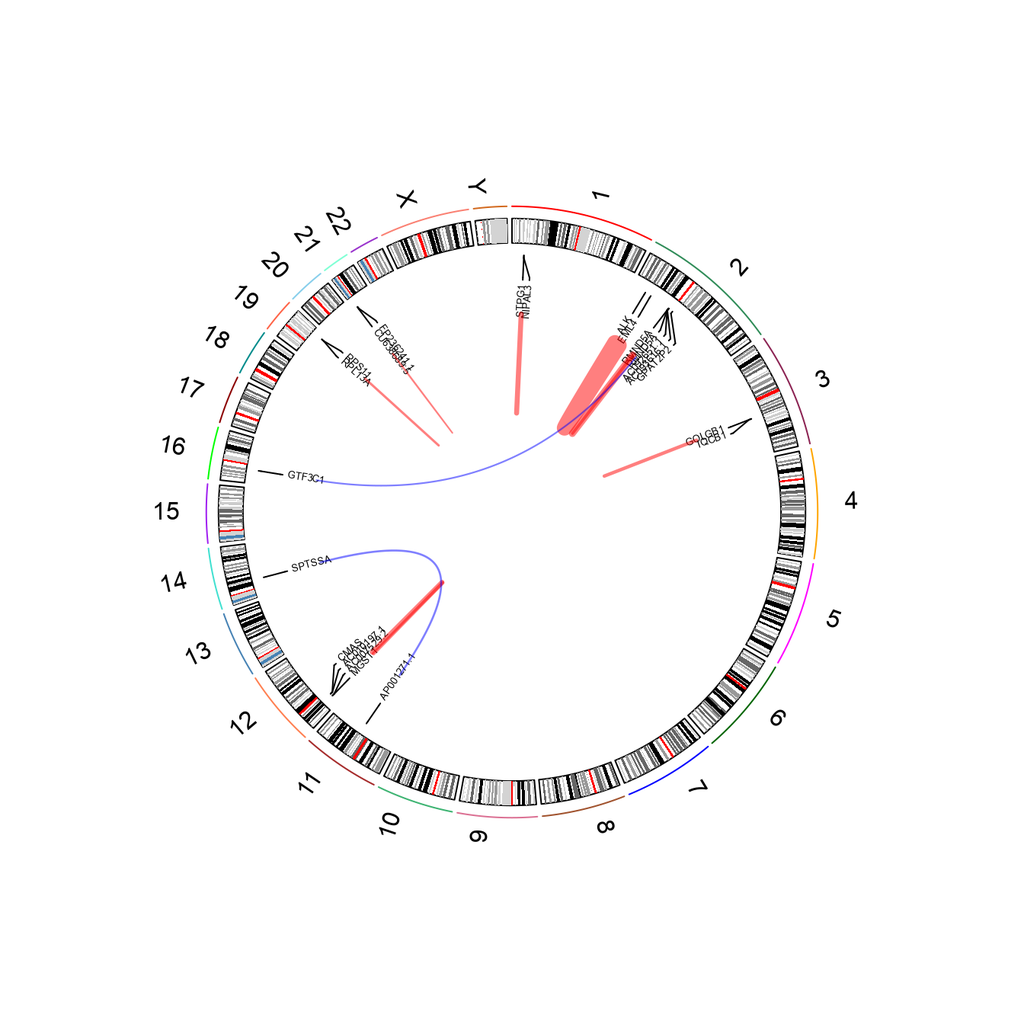

```r
# Load chimeraviz library
library(chimeraviz)

# Read STAR-fusion output
fusions <- import_starfusion(star_fusion_data_file, "hg38")

# Generate quick report with circus plot and table of top fusions
create_fusion_report(fusions,"chimeraviz_quick_report.html")
```

If you have spare time *after* this session, you may try making a *Chimeraviz* gene-pair plot for the cancer-driving fusion in this sample.

# 5. Counting transcripts with *Salmon*

Arguably, **gene expression analysis** could be considered as the most common application of short-read RNA-Seq in cancer research. **Gene expression analysis** starts with counting reads overlapping each gene (or transcript). Historically, the read counting tools used BAM files with alignments (e.g. as was implemented in *Cufflincs* or *RSEM*). However, “alignment-free” methods, such as *Kallisto* or *Salmon*, which use the raw reads from FASTQ files, are becaming more popular in recent years.

In this session we will use *Salmon*. Instead of relying on another tool for alignment, *Salmon* performs its own fast “quasi-mapping” to transcriptome:

- https://combine-lab.github.io/salmon
- https://salmon.readthedocs.io/en/latest/salmon.html

## 5.1 Preparing Salmon index

The **Salmon index** has already been prepared for you: you don’t need to prepare it again.

You may see the scripts used to prepare Salmon index in the folder **…/scripts/s03_transcripts_count**. These are scripts **s01**, **s02** and **s03**. Do NOT run these scripts! They are given just for you to know how the index was generated.

Breifly:  
- **s01_download_gencode.sh** - shows how the genome, transcriptome and annotations can be downloaded from Gencode,  
- **s02_add_decoys_to_transcriptome.sh** - shows how transcriptome was prepared for making Salmon index,  
- **s03_salmon_index.sh** : actually shows how to make the Salmon index.

Review the content of these scripts: they contain many comments and explanations.

## 5.2 Run Salmon quantification

The script for Salmon transcripts count is also located in **…/scripts/s03_transcript_counts** folder, you may run it using the following command:

```bash
./s04_salmon_quant.sh &> s04_salmon_quant.log # Run the script recording the output to a log
```

The counting is quick. The intended output folder is **…/results/s03_transcript_counts/SRR8615530_salmon_quant**.

The actual count is performed using **salmon quant** command:

```bash
salmon quant \
--index ${index_folder} \
--libType A \
--mates1 ${fastq_folder}/SRR8615530_sub_1.fq.gz \
--mates2 ${fastq_folder}/SRR8615530_sub_2.fq.gz \
--output ${quant_folder}/SRR8615530_salmon_quant \
--threads 12
```

For the informatin about *libType* option see  
* https://salmon.readthedocs.io/en/latest/salmon.html#what-s-this-libtype  
* https://salmon.readthedocs.io/en/latest/library_type.html

Explore the output folder after the run. Amongst the other files, there will be a **quant.sf** file. This is the result of **Salmon** quantification. Have a quick look at the content of this file (hint: you may use **head** command in the terminal).

Importantly, the output folder also contains **the information about genomic resources** used for counting (Gencode-45 in our case). This information will be automatically extracted from Salmon counts by R libraries, which will import the counts for differential expression analysis.

# 6. Differential gene expression with *DESeq2*

## 6.1 Overview

Detecting differentially expressed genes is an important branch of RNA-seq data analysis. The differentially expressed genes may explain the cancer biology, and they can be used for molecular classification of cancer, to evaluate prognosis or to predict response to treatment.

There are several statistical approaches for detecting differentially expressed genes (**DEGs**). We will use the approach implemented in **DESeq2** R package:

- it models counts using Negative Binomial distribution and
- it “shrinks” the dispersions toward the mean dispersion for the genes with similar levels of expression.

Both choices are empirical. It had been empirically observed that the real count data are better Described by the Negative Binomial than, for instance, by Normal or Poisson distributions. Also, at the early days of RNA-seq it was quite an expensive technique. The small numbers of replicas prevented finding significant results when the non-adjusted dispersions were used. So statisticians had to come up with a heuristic method to somehow shrink the dispersions for detecting **DEGs**.

In addition to the sophisticated mathematical methods, *DESeq2* package provides many convenience features for data pre-processing and assessment:  
https://bioconductor.org/packages/release/bioc/vignettes/DESeq2/inst/doc/DESeq2.html

## 6.2 R-markdown script

The code for our entire Differential Expression analysis is provided in this script:  
**…/scripts/s04_differential_gene_expression/DESeq2_analysis.Rmd**

Only selected fragments of this script will be discussed below. You are expected to go through the script, executing it interactively line-by-line. At the end, you may **knit** the script to produce a nicely-formatted **html** report. A copy of this report is available on a separate link in the practical session materials (and on **penelopeCloud**). You may follow the report, instead of the original script, if you prefer so.

## 6.3 Source data

Salmon counts for this analysis were prepared using RNA-seq data provided by Cancer Cell Line Encyclopedia (**CCLE**) project ( https://sites.broadinstitute.org/ccle ). This porject provides sequencing data for nearly 1000 of cancer cell lines, including DNA and RNA sequencing. The FASTQ files for Illumina RNA-seq data is publicly available. You already used RNA-seq data for one of the **CCLE** cell lines during the STAR and STAR-Fusion analysis.

For the Differential Gene Expression analysis I selected 6 lung cancer cell lines: 3 Lung Adenocarcinomas and 3 Small Cell Lung Carcinomas. Biologically, these are very differnet types of tumours. So, we may expect many differentially expressed genes. This is the summary of the selected samples:

| SRA | Depth | CCLE | Type | Subtype | Driver |
| --- | --- | --- | --- | --- | --- |
| SRR8615612 | 83,450,360 | NCIH1373 | Non-Small Cell Lung Cancer | Lung Adenocarcinoma | KRAS_p.G12C |
| SRR8616105 | 84,706,828 | NCIH23 | Non-Small Cell Lung Cancer | Lung Adenocarcinoma | KRAS_p.G12C |
| SRR8615805 | 109,186,348 | NCIH358 | Non-Small Cell Lung Cancer | Lung Adenocarcinoma | KRAS_p.G12C |
| SRR8616002 | 79,854,702 | DMS114 | Lung Neuroendocrine Tumor | Small Cell Lung Cancer |  |
| SRR8615428 | 77,000,229 | CORL311 | Lung Neuroendocrine Tumor | Small Cell Lung Cancer |  |
| SRR8615609 | 60,897,689 | NCIH1836 | Lung Neuroendocrine Tumor | Small Cell Lung Cancer |  |

The FASTQ files used for STAR had been significantly down-sampled to allow the alignment within a short practical session. The counts for Differential expression analysis were using the full FASTQ files. So, you can see that all samples were sequenced to > 60M reads depth.

The transcript counts generated by Salmon are located in folder **…/short-reads/data/salmon_counts**. The Salmon index was generated with Gencode v45.

## 6.4 Preparing R environment

The **Start section** of the script cleans the environment (just in case) and shows how the required packages were installed. The installation lines are commented because it was needed to be done just once. You dont need to install any libraries: it already had been done for you. The libraries are loaded in the chunks when they are used.

## 6.5 Reading data into *DESeq Data Set* object

The preferred tool for importing **Salmon** counts for **DESeq2** analysis is **tximeta** R package:  
https://bioconductor.org/packages/release/bioc/vignettes/tximeta/inst/doc/tximeta.html

**tximeta** can recognise the transcriptome version that was used during the counts preparation. The output of **tximeta** is a **Ranged Summarized Experiment** object, which contains the matrices with raw and TPM normalized counts, samples information, and genes IDs and coordinates. Because in our analysis Salmon used Gencode resources, the genes IDs are represented as Ensembl gene ID. So we will need to add the gene symbols/names. The script will discuss two approaches for adding gene names (and other genes annotations) to a **Summarized Experiment** object. The **Summarized Experiment** object then is placed into **DESeq Data Set** object.

## 6.6 Design formula

In addition to the **Summarized Experiment**, the **DESeq Data Set** object also requires a **design formula**, which describes the analysis that we will perform. The **design formula** is a **string** that follows the standard **R formula** syntax. In our case it describes a very simple design: compare gene expressions between two conditions provided in the **condition** column in the **colData** table (Adenocarcinoma vs Small Cell carcinoma). Hence, just **~condition** in the design string.

More commonly, the *design* may include several covariates. For instance, a design with batch-correction and adjustment for sex would look like this: **design = ~ batch + sex + condition**. Importantly, in designs with covariates the main factor of interest (**condition** in this example) should be kept at the end of the DESeq2 *design* formula.

In general, the statistical designs and **R formulas** is a very broad field, going far beyond the scope of this course. You may see some introductory points in the DESeq2 manual mentioned previously, and in these links:  
* https://www.datacamp.com/tutorial/r-formula-tutorial  
* https://f1000research.com/articles/9-1444/v1  
* https://bioconductor.org/packages/release/workflows/vignettes/RNAseq123/inst/doc/designmatrices.html

## 6.7 The remaining steps of DESeq2 analysis

The following steps are usually performed after placing the data (and the design formula) into *DESeq Data Set* object:  
* Removal of low-expressed genes  
* Data exploration (usually requires some transformations, e.g. applying VST to the TPM-normalized expressions)  
* Actual differential expression analysis (starts from RAW, non-transformed data!)  
* Selection of FC and FDR thresholds, and extraction of results for the downstream analysis  
* Visualizations (e.g. Volcano plots and Hierarchical clustering with Heatmaps)

Follow the provided **Rmd** script (and/or the separate HTML file/link) to see how these steps are done.

# 7. Functional analysis

The final part of this practical session includes biologic interpretation of the results of Differential Gene Expression analysis. Specifically, it shows **enrichment** analysis against **Gene Ontology** terms and against **KEGG** pathways. You will use two different technical approaches to the enrichment assessment: the **over-representation analysis** and the Gene Set Enrichment Analysis (**GSEA**). The analysis steps are given in the following Rmd script:  
**…/scripts/s05_functional_analysis/Functional_analysis.rmd**  
You may follow this script (and/or the corresponding HTML file/link) to complete this part of the practical.

# 8. Reproducible rersearch

The closing section of all R/Rmd scripts usually should call **sessionInfo()** function to record the versions of all libraries present in the environment: a good practice for **reproducible research**. It may also call **ls()**, **save.image()** and **Sys.time()** functions to record what objects were present in the environment during the analysis, and when it was done.